# IE360: Homework 1

Barış Arslan 2019402129

12/4/2022

## Required Packages

```r
library(readxl)
library(ggplot2)
library(GGally)
library(corrplot)
library(zoo)
library(lubridate)
```

## 1. Introduction

In the Homework 1 of IE360: Statistical Forecasting and Time Series course, four different data sets are obtained with respect the to the area of interest.  
Data sets are as follows:

- Debit Card and Credit Card Total Expenditure Amount on Car Rental over 2014-2022
- Weighted Average Interest Rates For Banks Loans (Vehicle) over 2014-2022
- Total Number of Tourist in Turkey over 2014-2022
- Google Trends Search Results for the keyword “Araba kiralama” over 2014-2022

First 3 data sets are obtained from Electronic Data Delivery System: https://evds2.tcmb.gov.tr/  
Last data set is obtained from Google Trends: https://trends.google.com/trends/

In this homework, the area of interest and research question is:  
**Is the total expenditure amount on car rental in Turkey correlated with the interest rates for vehicle loans and the total number of tourist in Turkey?**

## 2. Debit Card and Credit Card Total Expenditure Amount on Car Rental over 2014-2022

In this section, “Debit Card and Credit Card Total Expenditure Amount on Car Rental” data is analyzed. Total expenditure amounts are reported monthly in Thousand TRY units. Time range for the data is from March 2014 to January 2022.

## 2.1. Summary of the Data

```
## # A tibble: 12 x 2
##    Date      Amount
##    <yearmon>  <dbl>
##  1 Mar 2014   51358
##  2 Nis 2014   53961
##  3 May 2014   80331
##  4 Haz 2014   73968
##  5 Tem 2014   74499
##  6 Ağu 2014   92210
##  7 Eyl 2014   70097
##  8 Eki 2014   80996
##  9 Kas 2014   66788
## 10 Ara 2014   67057
## 11 Oca 2015   80387
## 12 Şub 2015   69406
```

```
## # A tibble: 12 x 2
##    Date      Amount
##    <yearmon>  <dbl>
##  1 Şub 2021  201962
##  2 Mar 2021  251710
##  3 Nis 2021  275513
##  4 May 2021  209700
##  5 Haz 2021  378046
##  6 Tem 2021  623898
##  7 Ağu 2021  486040
##  8 Eyl 2021  553073
##  9 Eki 2021  485494
## 10 Kas 2021  376383
## 11 Ara 2021  499816
## 12 Oca 2022  381309
```

```
##    Min. 1st Qu.  Median    Mean 3rd Qu.    Max.
##   51358  106800  158321  180123  205831  623898
```

```
## tibble[,2] [95 × 2] (S3: tbl_df/tbl/data.frame)
##  $ Date  : 'yearmon' num [1:95] Mar 2014 Nis 2014 May 2014 Haz 2014 ...
##  $ Amount: num [1:95] 51358 53961 80331 73968 74499 ...
```

## 2.2. Plot of the Data

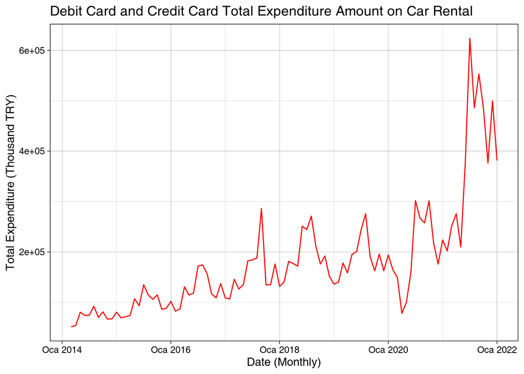

## 2.3. Yearly Boxplot of the Data

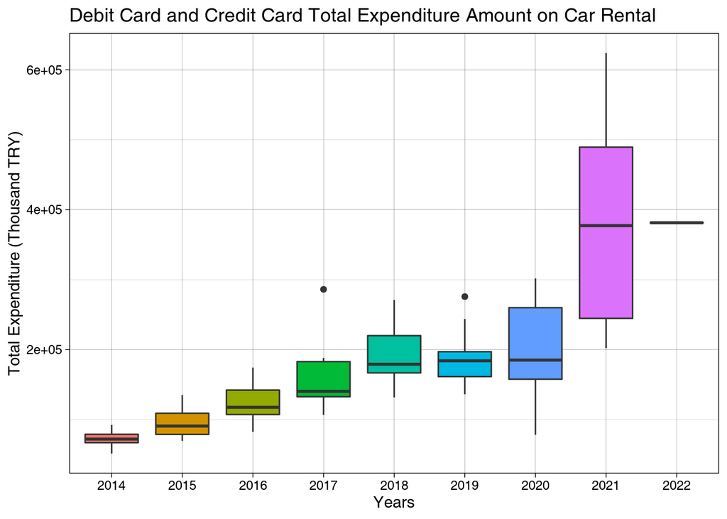

## 3. Weighted Average Interest Rates For Banks Loans (Vehicle) over 2014-2022

In this section, “Weighted Average Interest Rates For Banks Loans (Vehicle)” data is analyzed. Weighted average interest rates are reported monthly in percentages(%). Time range for the data is from March 2014 to January 2022.

## 3.1. Summary of the Data

```
## # A tibble: 12 x 2
##    Date      Rates
##    <yearmon> <dbl>
##  1 Mar 2014   15.2
##  2 Nis 2014   14.9
##  3 May 2014   14.3
##  4 Haz 2014   13.3
##  5 Tem 2014   12.8
##  6 Ağu 2014   12.8
##  7 Eyl 2014   12.7
##  8 Eki 2014   12.4
##  9 Kas 2014   12.4
## 10 Ara 2014   12.6
## 11 Oca 2015   12.9
## 12 Şub 2015   13.1
```

```
## # A tibble: 12 x 2
##    Date      Rates
##    <yearmon> <dbl>
##  1 Şub 2021   19.2
##  2 Mar 2021   19.4
##  3 Nis 2021   21.7
##  4 May 2021   22.4
##  5 Haz 2021   22.0
##  6 Tem 2021   22.3
##  7 Ağu 2021   21.8
##  8 Eyl 2021   21.3
##  9 Eki 2021   20.7
## 10 Kas 2021   21.5
## 11 Ara 2021   24.8
## 12 Oca 2022   28.2
```

```
##    Min. 1st Qu.  Median    Mean 3rd Qu.    Max.
##   11.61   14.10   15.69   17.83   21.03   32.78
```

```
## tibble[,2] [95 × 2] (S3: tbl_df/tbl/data.frame)
##  $ Date : 'yearmon' num [1:95] Mar 2014 Nis 2014 May 2014 Haz 2014 ...
##  $ Rates: num [1:95] 15.2 14.9 14.3 13.3 12.8 ...
```

## 3.2. Plot of the Data

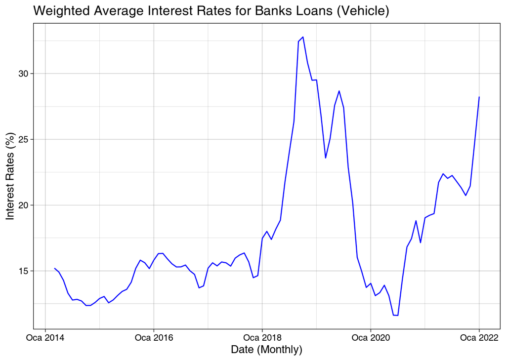

## 3.3. Yearly Boxplot of the Data

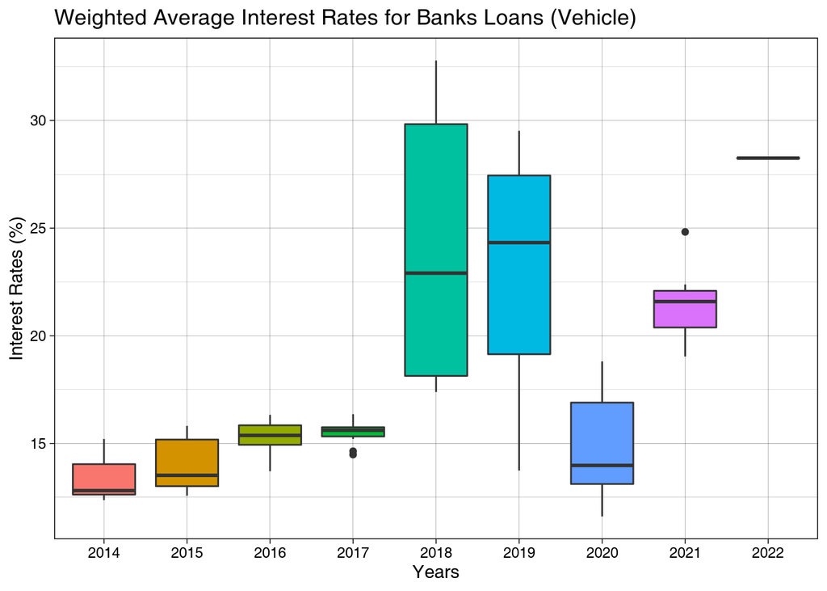

## 4. Total Number of Tourists in Turkey over 2014-2022

In this section, “Total Number of Tourists in Turkey” data is analyzed. Total number of tourists data is reported monthly. Time range for the data is from March 2014 to January 2022.

## 4.1. Summary of the Data

```
## # A tibble: 12 x 2
##    Date      Tourists
##    <yearmon>    <dbl>
##  1 Mar 2014   1677890
##  2 Nis 2014   2244712
##  3 May 2014   3520669
##  4 Haz 2014   4160935
##  5 Tem 2014   4320918
##  6 Ağu 2014   5717412
##  7 Eyl 2014   4626281
##  8 Eki 2014   3840928
##  9 Kas 2014   1901420
## 10 Ara 2014   1376487
## 11 Oca 2015   1382909
## 12 Şub 2015   1256944
```

```
## # A tibble: 12 x 2
##    Date      Tourists
##    <yearmon>    <dbl>
##  1 Şub 2021    494337
##  2 Mar 2021    761443
##  3 Nis 2021    895342
##  4 May 2021    757518
##  5 Haz 2021   1491955
##  6 Tem 2021   3231555
##  7 Ağu 2021   4578265
##  8 Eyl 2021   3648131
##  9 Eki 2021   3777732
## 10 Kas 2021   2080510
## 11 Ara 2021   1652786
## 12 Oca 2022   1593112
```

```
##    Min. 1st Qu.  Median    Mean 3rd Qu.    Max.
##   50630 1485492 2081631 2615390 3804986 7018257
```

```
## tibble[,2] [95 × 2] (S3: tbl_df/tbl/data.frame)
##  $ Date    : 'yearmon' num [1:95] Mar 2014 Nis 2014 May 2014 Haz 2014 ...
##  $ Tourists: num [1:95] 1677890 2244712 3520669 4160935 4320918 ...
```

## 4.2. Plot of the Data

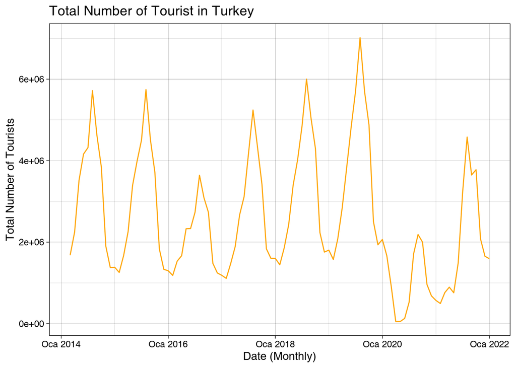

## 4.3. Yearly Boxplot of the Data

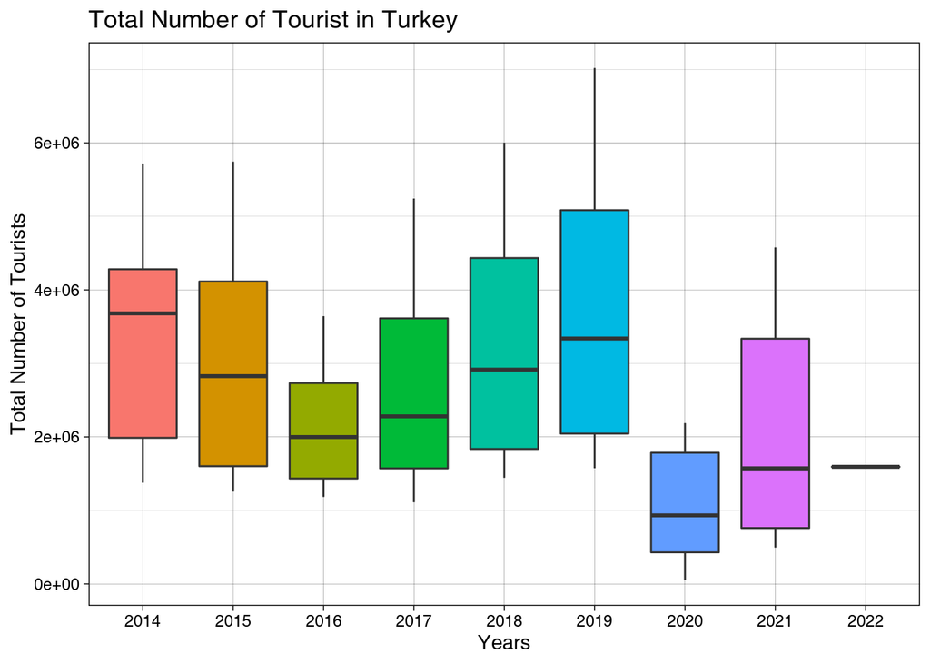

## 5. Google Trends Search Results for the keyword “Araba kiralama” over 2014-2022

In this section, Google Trends search results for the keyword “Araba kiralama” is analyzed. Search results for “Araba kiralama” keyword are reported monthly. Time range for the data is from March 2014 to January 2022.

## 5.1. Summary of the Data

```
##       Month Keyword
## 1  Mar 2014      19
## 2  Nis 2014      26
## 3  May 2014      30
## 4  Haz 2014      35
## 5  Tem 2014      53
## 6  Ağu 2014      47
## 7  Eyl 2014      30
## 8  Eki 2014      26
## 9  Kas 2014      20
## 10 Ara 2014      21
## 11 Oca 2015      19
## 12 Şub 2015      21
```

```
##       Month Keyword
## 84 Şub 2021      26
## 85 Mar 2021      31
## 86 Nis 2021      26
## 87 May 2021      38
## 88 Haz 2021      65
## 89 Tem 2021      98
## 90 Ağu 2021      68
## 91 Eyl 2021      37
## 92 Eki 2021      29
## 93 Kas 2021      25
## 94 Ara 2021      24
## 95 Oca 2022      24
```

```
##    Min. 1st Qu.  Median    Mean 3rd Qu.    Max.
##   16.00   26.00   31.00   38.34   45.00  100.00
```

```
##  int [1:95] 19 26 30 35 53 47 30 26 20 21 ...
```

## 5.2. Plot of the Data

[figure not shown]

## 5.3. Yearly Boxplot of the Data

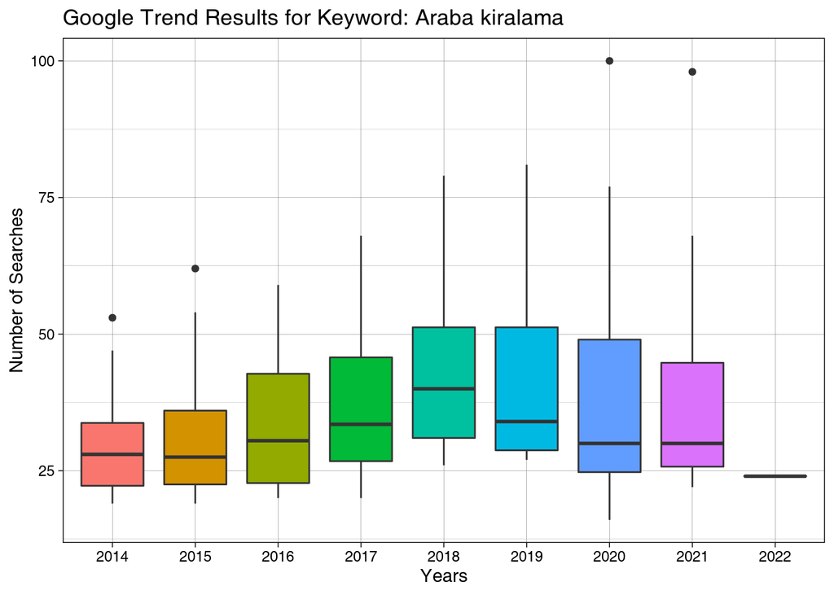

## 6. Conclusion

In the first section, “Debit Card and Credit Card Total Expenditure Amount on Car Rental” data follows a generally increasing trend. However there is a serious decrease in the first quarter of the year 2020. It can be explained by the globally affecting COVID-19 pandemic. In addition to the affects of the pandemic, there is a rapid increase after the 2021. Main reason for this behavior is the increase in the inflation rate for Turkish Lira (TRY).  
In the third section, “Total Number of Tourists in Turkey” data has a seasonality factor. Total number of tourists increase around summers and then decreases around winters. However, there is also a major decrease after 2020 because of the COVID-19 pandemic. There are some levels of similarities with Google Trends results.  
In the last section, “Google Trend Results for Keyword: Araba kiralama” data is plotted. There can be seen a similar seasonality with the “Total Number of Tourists in Turkey” data. “Araba kiralama” searches increase around summers and then decreases on winters similar to previous section. However, there is an increase after 2020 in contrast with the previous section. It can be explained with the increasing trend in the “Debit Card and Credit Card Total Expenditure Amount on Car Rental” and inflation rate in Turkey after 2020.  
In conclusion, the correlation between total expenditure on car rental, interest rates for vehicle, and total number of tourists are examined in this homework. According to the results of the correlation matrix and behavior of the data, there is not a strong correlation between the data sets.  
Even though a strong correlation is not observed, there are moderate level correlations between some data sets:

- Between “Debit Card and Credit Card Total Expenditure Amount on Car Rental” data and “Weighted Average Interest Rates for Banks Loans (Vehicle)” data, there is a moderate level correlation.
- Between “Debit Card and Credit Card Total Expenditure Amount on Car Rental” data and “Google Trend Results for Keyword: Araba kiralama” data, there is a moderate level correlation.
- Between “Total Number of Tourists in Turkey” data and “Google Trend Results for Keyword: Araba kiralama” data, there is a moderate level correlation.

## 6.1. Scatterplot Matrix and Correlation

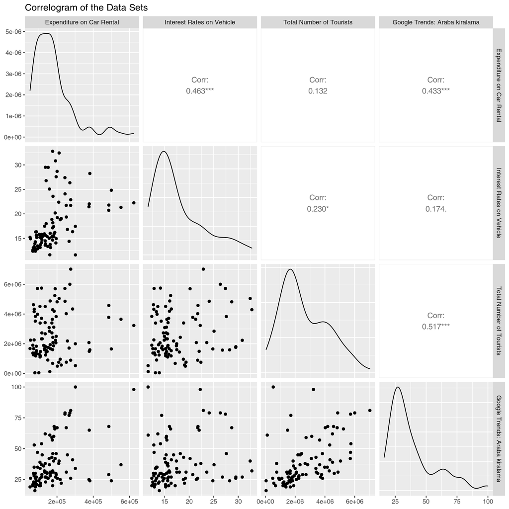

## Additional Notes

My RMarkdown file is located at the progress journal. [Click here](https://bu-ie-360.github.io/spring22-BarisArslan/HW1/HW1_Baris_Arslan.Rmd)